# Exercise 3: Marketing A/B Testing

2026-06-22

# 1. Load the data

```r
marketing <- read_csv("marketing_AB_mini.csv")

dim(marketing)
```

```
## [1] 58810     6
```

```r
head(marketing)
```

```
## # A tibble: 6 × 6
##   `user id` `test group` converted `total ads` `most ads day` `most ads hour`
##       <dbl> <chr>        <lgl>           <dbl> <chr>                    <dbl>
## 1   1317070 ad           FALSE              36 Sunday                      14
## 2    903624 psa          FALSE              16 Tuesday                     16
## 3   1242031 ad           FALSE               7 Saturday                    20
## 4   1379296 ad           FALSE              13 Thursday                     0
## 5   1162733 ad           FALSE              24 Sunday                      15
## 6   1150469 ad           FALSE               2 Tuesday                     12
```

```r
summary(marketing)
```

```
##     user id         test group        converted         total ads
##  Min.   : 900021   Length:58810       Mode :logical   Min.   :   1.00
##  1st Qu.:1144910   Class :character   FALSE:57320     1st Qu.:   4.00
##  Median :1315774   Mode  :character   TRUE :1490      Median :  13.00
##  Mean   :1311449                                      Mean   :  24.58
##  3rd Qu.:1483677                                      3rd Qu.:  27.00
##  Max.   :1654466                                      Max.   :1391.00
##  most ads day       most ads hour
##  Length:58810       Min.   : 0.0
##  Class :character   1st Qu.:11.0
##  Mode  :character   Median :14.0
##                     Mean   :14.5
##                     3rd Qu.:18.0
##                     Max.   :23.0
```

```r
table(marketing$`test group`)
```

```
##
##    ad   psa
## 56492  2318
```

```r
table(marketing$converted)
```

```
##
## FALSE  TRUE
## 57320  1490
```

The dataset has 58810 rows and 6 columns. The A/B variable is `test group`, where `ad` is the advertising treatment and `psa` is the control condition. The main outcome variable is `converted`.

# 2. Research question and parameter choice

The research question is:

**Does the advertising treatment increase the conversion rate compared with the PSA/control group?**

Because `converted` is a binary variable, the most suitable parameter is the conversion proportion in each group. The A/B effect is measured as:

```r
conversion_summary <- aggregate(
  converted ~ `test group`,
  data = marketing,
  FUN = mean
)
names(conversion_summary)[2] <- "conversion_rate"

group_counts <- aggregate(
  converted ~ `test group`,
  data = marketing,
  FUN = length
)
names(group_counts)[2] <- "n"

conversion_counts <- aggregate(
  converted ~ `test group`,
  data = marketing,
  FUN = sum
)
names(conversion_counts)[2] <- "conversions"

ab_summary <- merge(group_counts, conversion_counts, by = "test group")
ab_summary <- merge(ab_summary, conversion_summary, by = "test group")
ab_summary$conversion_percent <- 100 * ab_summary$conversion_rate

print(ab_summary)
```

```
##   test group     n conversions conversion_rate conversion_percent
## 1         ad 56492        1453      0.02572046           2.572046
## 2        psa  2318          37      0.01596204           1.596204
```

```r
fmt_percent <- function(x) sprintf("%.2f", 100 * x)
fmt_pvalue <- function(x) sprintf("%.4f", x)

ad_rate <- ab_summary$conversion_rate[ab_summary$`test group` == "ad"]
psa_rate <- ab_summary$conversion_rate[ab_summary$`test group` == "psa"]
observed_diff <- ad_rate - psa_rate

observed_diff
```

```
## [1] 0.00975842
```

The observed conversion rate is 2.57% in the `ad` group and 1.60% in the `psa` group. The observed difference is 0.98 percentage points.

# 3. Visual comparison

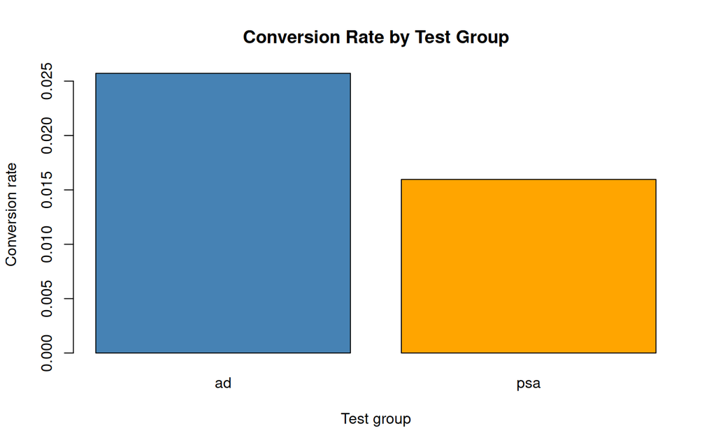

```r
barplot(
  ab_summary$conversion_rate,
  names.arg = ab_summary$`test group`,
  col = c("steelblue", "orange"),
  main = "Conversion Rate by Test Group",
  xlab = "Test group",
  ylab = "Conversion rate"
)
```

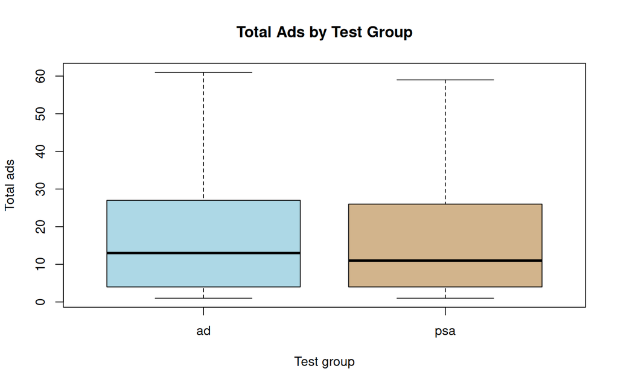

```r
boxplot(
  `total ads` ~ `test group`,
  data = marketing,
  col = c("lightblue", "tan"),
  main = "Total Ads by Test Group",
  xlab = "Test group",
  ylab = "Total ads",
  outline = FALSE
)
```

The first plot compares the main A/B metric. The second plot is a supporting diagnostic because the distribution of `total ads` is right-skewed and contains large values. This makes the conversion proportion more appropriate than the mean or variance of ad exposure for the main A/B conclusion.

# 4. Permutation test

The null hypothesis is that the treatment label has no relationship with conversion. Under this null hypothesis, the `converted` values can be randomly reassigned across the two groups while keeping the original group sizes fixed.

```r
set.seed(42)

n_perm <- 10000
group_labels <- marketing$`test group`
converted_values <- marketing$converted

permutation_diffs <- numeric(n_perm)

for (i in seq_len(n_perm)) {
  shuffled_conversion <- sample(converted_values, replace = FALSE)

  perm_ad_rate <- mean(shuffled_conversion[group_labels == "ad"])
  perm_psa_rate <- mean(shuffled_conversion[group_labels == "psa"])

  permutation_diffs[i] <- perm_ad_rate - perm_psa_rate
}

p_value_two_sided <- mean(abs(permutation_diffs) >= abs(observed_diff))
p_value_one_sided <- mean(permutation_diffs >= observed_diff)

p_value_two_sided
```

```
## [1] 0.0035
```

```r
p_value_one_sided
```

```
## [1] 8e-04
```

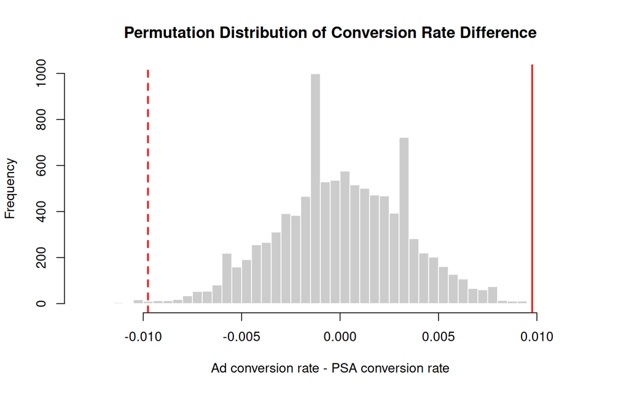

```r
hist(
  permutation_diffs,
  breaks = 50,
  col = "gray80",
  border = "white",
  main = "Permutation Distribution of Conversion Rate Difference",
  xlab = "Ad conversion rate - PSA conversion rate"
)
abline(v = observed_diff, col = "red", lwd = 2)
abline(v = -observed_diff, col = "red", lwd = 2, lty = 2)
```

The two-sided permutation p-value is 0.0035. The one-sided p-value for the alternative that the ad group has a higher conversion rate is 0.0008.

# 5. Bootstrap confidence interval

Bootstrap resampling estimates the uncertainty of the observed difference in conversion rates. Users are resampled within each group so that the group structure remains the same.

```r
set.seed(42)

n_boot <- 10000
ad_converted <- marketing$converted[marketing$`test group` == "ad"]
psa_converted <- marketing$converted[marketing$`test group` == "psa"]

bootstrap_diffs <- numeric(n_boot)

for (i in seq_len(n_boot)) {
  boot_ad <- sample(ad_converted, size = length(ad_converted), replace = TRUE)
  boot_psa <- sample(psa_converted, size = length(psa_converted), replace = TRUE)

  bootstrap_diffs[i] <- mean(boot_ad) - mean(boot_psa)
}

bootstrap_ci <- quantile(bootstrap_diffs, c(0.025, 0.975))
bootstrap_ci
```

```
##        2.5%       97.5%
## 0.004399796 0.014762961
```

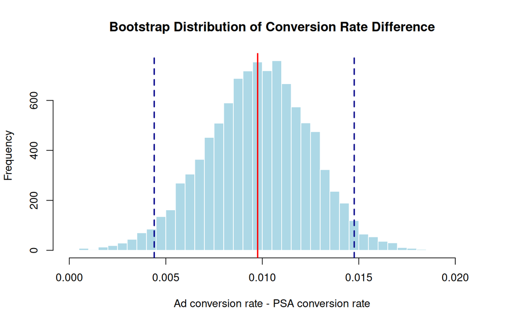

```r
hist(
  bootstrap_diffs,
  breaks = 50,
  col = "lightblue",
  border = "white",
  main = "Bootstrap Distribution of Conversion Rate Difference",
  xlab = "Ad conversion rate - PSA conversion rate"
)
abline(v = observed_diff, col = "red", lwd = 2)
abline(v = bootstrap_ci, col = "darkblue", lwd = 2, lty = 2)
```

The 95% bootstrap confidence interval for the difference in conversion rates is from 0.44 to 1.48 percentage points.

# 6. Comments and conclusion

- **Parameter selection:** The conversion proportion is the correct primary parameter because the outcome `converted` is binary. Mean, median, and variance are less suitable for the main A/B question because they describe numeric variables such as `total ads`, not the final conversion outcome.
- **Observed A/B result:** The `ad` group has a conversion rate of 2.57%, while the `psa` group has a conversion rate of 1.60%. The observed lift is 0.98 percentage points in favor of the ad group.
- **Permutation test:** The two-sided permutation p-value is 0.0035. This tests whether a difference at least as large as the observed difference would be likely if the group labels had no relationship with conversion. The one-sided p-value is 0.0008, which directly matches the question of whether the ad group performs better than the PSA/control group.
- **Bootstrap interval:** The 95% bootstrap confidence interval is [0.44, 1.48] percentage points. Because the interval is above zero, the mini dataset supports a positive advertising effect on conversion.
- **Final conclusion:** Based on the mini dataset, the advertising treatment has a higher conversion rate than the PSA/control condition. The permutation test and bootstrap confidence interval both support the conclusion that this observed difference is unlikely to be explained by random assignment alone. However, the result should still be interpreted in the context of this 10% sample rather than the full original dataset.